# HPC Mapping Rating Area Pipeline

RWang

May 20, 2019

## Urbnthemes

Need urbnthemes for styling Instructions: https://github.com/UrbanInstitute/urban_R_theme

install.packages(c(“ggplot2”,“reshape2”,“RColorBrewer”,“extrafont”)) may be needed

```r
# source('https://raw.githubusercontent.com/UrbanInstitute/urban_R_theme/master/urban_theme_windows.R')
library(urbnthemes)
```

## Libraries

```r
library(tidyr)
#library(plyr)
library(dplyr)
library(tidyverse)
library(sf)
library(tidycensus)
```

```r
library(ggplot2)
library(here)
library(readxl)
library(readr)
library(readxl)
library(units)
library(smoothr)
library(rmapshaper)
library(magick)
devtools::install_github("uncoast-unconf/ggcart")
library(ggcart)
```

## Census API Input

Acquire your own API: https://api.census.gov/data/key_signup.html TidyCensus: https://cran.r-project.org/web/packages/tidycensus/tidycensus.pdf

## Census API Data

Bespoke lines needed to address Kusilvak and Oglala, for cross walk with HPC RA level data

```r
counties <- tidycensus::get_acs(geography = "county", variables = "B19013_001",
                                geometry = TRUE) %>% arrange(NAME)
counties$NAME_orig <- counties$NAME

counties <- counties %>% separate(NAME, into = c("county", "state"),sep="\\,")
counties$state <- trimws(counties$state, which = c("left"))

# inspect states
unique(counties$state)

# Remove Puerto Rico
counties <- counties %>% filter(state != "Puerto Rico")
# Alaska
counties$county[counties$GEOID=="02158"] <- "Kusilvak, formerly Wade Hampton 02270"
# South Dakota
counties$county[counties$GEOID=="46102"] <- "Oglala Lakota County, formerly Shannon 46113"

unique(counties$state)
length(unique(counties$state))


# State Data, used only for Alaska Cropping
states <- tidycensus::get_acs(geography = "state", variables = "B19013_001",
                                geometry = TRUE) %>% arrange(NAME)
states <- states %>% filter(NAME != "Puerto Rico")
```

## Set-up All Counties

Not fetching for VT, RI, NJ, HI, DC, DE; with only one rating area in state (https://www.cms.gov/cciio/programs-and-initiatives/health-insurance-market-reforms/state-gra.html) Need to take care of California, Nebraska, Massachusetts and Alaska separately

```r
# Only 1
only1 <- c("Vermont","Rhode Island","New Jersey","Hawaii",
           "District of Columbia","Delaware","New Hampshire")

only1data_factory <- function(df,name) {
  statedata <- df %>% filter(state == name)
  group1 <- statedata$GEOID
  statedata <- statedata %>% mutate(group = case_when(GEOID %in% group1 ~ 'newgroup1',TRUE ~ GEOID))
  statedata2 <- group_by(statedata, group) %>% summarise(estimate=sum(estimate), do_union = TRUE)
  statedata_merge <- statedata2 %>% mutate(facet = "merged") %>% dplyr::select("group","estimate","facet","geometry")
  statedata_unmerge <- statedata %>% dplyr::select(group,estimate) %>% mutate(facet = "unmerge")
  statedata_output <- rbind(statedata_merge, statedata_unmerge)
  statedata_output$ratingarea <- 1
  statedata_output$state <- name
  statedata_output <- statedata_output %>% dplyr::select(-c("group"))
  statedata_output <- statedata_output[c("state","ratingarea","facet","estimate","geometry")]
  statedata_output$ratingarea <- as.factor(statedata_output$ratingarea)
  return(statedata_output)
  }

# Examine how many counties there are for benchmarking
other <- filter(counties,!(state %in% only1))["state"]
other <- unique(other$state)
other

county_counteur <- function(df,name) {
  statedata <- df %>% filter(state == name)
  count <- length(unique(statedata$county))
  return(list(name, count))
}

othercounties <- filter(counties,!(state %in% only1))
```

## ESRI shp 3-DIGIT for AK

3-digit area shapefiles from ESRI, only use for Alaska’s boundaries

```r
ESRIshp <- st_read("data/SHP3-digitESRI/Export_3DigitShpAK.shp") %>%
  dplyr::select(ZIP3,STATE,Shape_Area,geometry)
ESRIshp <- ESRIshp %>% filter(ZIP3 %in% c("000","995","996","997","998","999"))
ESRIshp$STATE <- as.character(ESRIshp$STATE)
ESRIshp$ZIP3 <- as.character(ESRIshp$ZIP3)
# AK shape, to be used as clipper for 3 digit zip shape file
AK_state <- states %>% filter(NAME == "Alaska")

ESRIshp_AK <- st_transform(ESRIshp,st_crs(AK_state))
# st_crs(ESRIshp_AK)
# st_crs(AK_state)
ESRIshp_AK <- st_crop(ESRIshp_AK,AK_state)
```

```
## although coordinates are longitude/latitude, st_intersection assumes that they are planar
```

```r
colnames(ESRIshp_AK)[1] <- "zip3"

AKzip3_to_RA <- read_excel("data/AKzip3-RA-crosswalk.xlsx")
# Use left join to preserve large areas in AK without zip code assignment
AKshp <- left_join(ESRIshp_AK,AKzip3_to_RA,by="zip3")
AKshp$STATE <- "AK"
AKshp <- group_by(AKshp,RA) %>% summarise(estimate=sum(Shape_Area),do_union = TRUE)
AKshp$RA <- as.factor(AKshp$RA)

#ggplot() + geom_sf(data = AKshp, aes(fill = RA), color = 'white')

rm(AK_state,AKzip3_to_RA,ESRIshp_AK)
```

## Los Angeles County Shapefile

RELY ON ARCMAP SHAPEFILES, CONVERT TO R MULTIPOLYGON AND WRANGLE… Los Angeles County GIS Data Portal : https://egis3.lacounty.gov/dataportal/2016/08/11/zip-codes-with-parcel-specific-boundaries/ Reference Zip Code Map in Los Angeles County : http://planning.lacounty.gov/assets/upl/data/map_t06-cities-zip.pdf

Then because of the strange grouping for region 923 & 928 per CMS, we use map from CoveredCA: https://hbex.coveredca.com/toolkit/webinars-briefings/downloads/Regional-Staff-FINAL.pdf

```r
CALAshp <-
  st_read("data/ZipCode_CA_LACounty/CAMS_ZIPCODE_PARCEL_SPECIFIC/CAMS_ZIPCODE_PARCEL_SPECIFIC.shp") %>%
  dplyr::select(ZIPCODE,OBJECTID,geometry)
CALAshp$group <- 1
CALAshp$zip3 <- substr(CALAshp$ZIPCODE,1,3)
# ggplot() + geom_sf(data = CALAshp, aes(fill = group), color = 'white') + scale_fill_viridis_c()

# Keeping lines below for referencing odd regional assignment, 928 and 923
# CALAshpmerge <- group_by(CALAshp,zip3) %>% summarise(estimate=sum(group), do_union = TRUE)
# ggplot() + geom_sf(data = CALAshpmerge, aes(fill = zip3), color = 'white')
# ggplot() + geom_sf(data = CALAshpmerge, aes(fill = zip3), color = 'white')
# CALAshpmerge %>% filter(zip3 == "928")%>% ggplot + geom_sf(aes(fill=zip3),color="white")
# CALAshpmerge %>% filter(zip3 == "923")%>% ggplot + geom_sf(aes(fill=zip3),color="white")

CALAzip3_to_RA <- read_excel("data/CALAzip3-RA-crosswalk.xlsx")
CALAshp <- merge(CALAshp,CALAzip3_to_RA,by="zip3")
CALAshp <- group_by(CALAshp,RA) %>% summarise(estimate=sum(group),do_union = TRUE)

CALAshp1 <- CALAshp
CALAshp1$state <- "California"
CALAshp1$do_union <- NULL
CALAshp1$facet <- "merged"
colnames(CALAshp1)[1] <- "ratingarea"
#ggplot() + geom_sf(data = CALAshp1, aes(fill = estimate), color = 'white') + scale_fill_viridis_c()
rm(CALAzip3_to_RA,CALAshp)
```

## MA Shapefile

RELY ON ARCMAP SHAPEFILES, CONVERT TO R MULTIPOLYGON AND WRANGLE… MASS GIS Pilot Data : https://docs.digital.mass.gov/dataset/massgis-data-zip-codes-5-digit-here-navteq

```r
MAshp <-
  st_read("data/zipcodes_MA/ZIPCODES_NT_POLY.shp") %>% dplyr::select(POSTCODE,PC_NAME,COUNTY,geometry)
MAshp1585 <- MAshp %>%
  filter(POSTCODE == "01585") %>% ms_filter_islands(min_area = units::set_units(1,km^2)) %>%
  drop_crumbs(set_units(5,km^2))
MAshp <- filter(MAshp,POSTCODE != "01585") %>% rbind(MAshp1585)

MAshp$group <- 1
MAshp$zip3 <- substr(MAshp$POSTCODE,1,3)
MAshp$zip3[MAshp$zip3 == "121"] <- "012"
MAshp2 <- group_by(MAshp,zip3) %>% summarise(estimate=sum(group),do_union = TRUE)
# ggplot() + geom_sf(data = MAshp2, aes(fill = estimate), color = 'white') + scale_fill_viridis_c()

MAzip3_to_RA <- read_excel("data/MAzip3-RA-crosswalk.xlsx")
MAshp3 <- merge(MAshp2,MAzip3_to_RA,by="zip3") %>% dplyr::select(-c("do_union"))
MAshp3 <- group_by(MAshp3,RA) %>%
  summarise(estimate=sum(estimate),do_union = TRUE) %>%
  fill_holes(threshold = units::set_units(200,km^2))
#ggplot() + geom_sf(data = MAshp3, aes(fill = estimate), color = 'white') + scale_fill_viridis_c()

rm(MAshp1585,MAshp,MAshp2,MAzip3_to_RA)
```

## NE Shapefile

RELY ON ARCMAP SHAPEFILES, CONVERT TO R MULTIPOLYGON AND WRANGLE… NE DEPT OF NATURAL RESOURCES : https://dnr.nebraska.gov/data/boundaries

```r
NEshp <- st_read("data/ZipCodesSP_NE/ZipCodesSP.shp") %>%
  dplyr::select(ZCTA5CE10,ALAND10,AWATER10,geometry)
NEshp$group <- 1
NEshp$zip3 <- substr(NEshp$ZCTA5CE10,1,3)
NEshp$zip3 <- as.numeric(NEshp$zip3)

NEshp$zip3[NEshp$zip3 == 570] <- 687
NEshp$zip3[NEshp$zip3 == 515] <- 680
NEshp$zip3[NEshp$zip3 == 665] <- 683
NEshp$zip3[NEshp$zip3 == 807] <- 690
NEshp$zip3[NEshp$zip3 == 820] <- 691

NEzip3_to_RA <- read_excel("data/NEzip3-RA-crosswalk.xlsx")
NEshp <- merge(NEshp,NEzip3_to_RA,by="zip3")
NEshp <-
  group_by(NEshp,RA) %>%
  summarise(estimate=sum(group),do_union = TRUE) %>%
  fill_holes(threshold = units::set_units(135,km^2))

#ggplot() + geom_sf(data = NEshp, aes(fill = estimate), color = 'white')
rm(NEzip3_to_RA)
```

## CA Harmonise and Edit

```r
CAOrig <- othercounties %>% filter(state == "California")
CALAOrig <- CAOrig %>% filter(GEOID == "06037")

# County CALA file has wrong crs, NEED RESET AND REPROJECT
# CALAshp1
CALAshp1 <- st_transform(CALAshp1,st_crs(CAOrig)$epsg)
# Drop LA County and Merge Edited
CAOrig$geometry[CAOrig$GEOID == "06037"] <- CALAshp1$geometry[CALAshp1$ratingarea==15]
CAOrig$county[CAOrig$GEOID == "06037"] <- "Los Angeles County - 15"
CAOrig$GEOID[CAOrig$GEOID == "06037"] <- "0603715"

CAmerge <- rbind(CAOrig,CALAOrig)
CAmerge$geometry[CAmerge$GEOID == "06037"] <- CALAshp1$geometry[CALAshp1$ratingarea==16]
CAOrig$county[CAOrig$GEOID == "06037"] <- "Los Angeles County - 16"
CAmerge$GEOID[CAmerge$GEOID == "06037"] <- "0603716"

othercounties <- filter(othercounties, state!="California")
othercounties <- rbind(othercounties,CAmerge)
rm(CAOrig,CALAOrig,CAmerge)
```

## Crosswalk & Validation Set-Up

```r
df_validation_census <-
  data.frame(matrix(unlist(map(other, function(x) county_counteur(othercounties, x))),
                    nrow = length(map(other, function(x) county_counteur(othercounties, x))),
                    byrow = T))
colnames(df_validation_census) <- c("state","NumCounty")
df_validation_census <- df_validation_census[order(df_validation_census$state),]

# Based on df above, construct reference matrix
# Reference CMS Rating Area Page if needed : https://www.cms.gov/cciio/programs-and-initiatives/health-insurance-market-reforms/state-gra.html
# Now simply take HPC county_to_RA_crosswalk, courtesy to Caroline and Erik

here()
county2RA <- read_excel("data/county_to_RA_crosswalk.xlsx")
county2RA <- county2RA[complete.cases(county2RA),]
county2RA$state <- trimws(gsub("[[:digit:]]","",county2RA$RatingRegion), which = c("right"))
county2RA$ratingarea <- readr::parse_number(county2RA$RatingRegion)
#Alaska
county2RA$fcounty[county2RA$fipscode=="02270"] <- "Kusilvak, formerly Wade Hampton 02270"
county2RA$fipscode[county2RA$fipscode=="02270"] <- "02158"
#South Dakota
county2RA$fcounty[county2RA$fipscode=="46113"] <- "Oglala Lakota County, formerly Shannon 46113"
county2RA$fipscode[county2RA$fipscode=="46113"] <- "46102"
#Virginia - Bedford city now in Bedford County
county2RA <- filter(county2RA,fipscode!="51515")
```

## Function - Other States

```r
othercounties_factory <- function(df,name) {
  statedata <- df %>% filter(state == name)
  ref_state <- county2RA %>% filter(state == name)
  if (name != "California") {
    if (length(ref_state$fcounty) != length(unique(ref_state$fcounty))) {
      stop("The County2RA reference file is wrong, examine and take care of duplicates or consistency between files.", call. = FALSE)
    }
    if (unlist(filter(df_validation_census,state==name)["NumCounty"])!=length(ref_state$fcounty)) {
      stop(paste0("Check file consistency. The files may not have complete records for at least ", name),call. = FALSE)
    }
  } else {
    if (length(ref_state$fcounty) != length(unique(ref_state$fcounty)) + 1) {
      stop("The County2RA reference file is wrong, examine and take care of duplicates or consistency between files.", call. = FALSE)
    }
  }
  if (unlist(filter(df_validation_census,state==name)["NumCounty"])!=length(ref_state$fcounty)) {
    stop(paste0("Check file consistency. The files may not have complete records for at least ", name),call. = FALSE)
  }

  statedata <- merge(statedata,dplyr::select(ref_state,-c("state")),
                     by.x=c("GEOID"),by.y=c("fipscode"))
  #print(dim(dplyr::select(statedata,-c("geometry")))[1])
  #print(length(ref_state$fcounty))
  #return(statedata)

  if (dim(dplyr::select(statedata,-c("geometry")))[1] != length(ref_state$fcounty)) {
    stop(paste0("Need to examine merge. The merged file does not have the correct number of counties for ",name))
    cat("\n")
    message(paste0("Processed polygon data ", dim(dplyr::select(statedata,-c("geometry")))[1]))
    cat("\n")
    message(paste0("retrieved reference data ", length(ref_state$fcounty)))
  }
  statedata_merge <- group_by(statedata,ratingarea) %>% summarise(estimate = sum(estimate), do_union = TRUE)

  statedata_merge <- statedata_merge %>% mutate(facet = "merged") %>% dplyr::select("ratingarea","estimate","facet","geometry")
  statedata_unmerge <- statedata %>% dplyr::select(ratingarea,estimate) %>% mutate(facet = "unmerge")
  statedata_output <- rbind(statedata_merge,statedata_unmerge)
  statedata_output$state <- name
  statedata_output <- statedata_output[c("state","ratingarea","facet","estimate","geometry")]
  statedata_output$ratingarea <- as.factor(statedata_output$ratingarea)
  return(statedata_output)
  }
```

## Test & Debug

```r
#input_state <- "California"
#test_output <- othercounties_factory(othercounties,input_state)
#ggplot() + geom_sf(data = filter(test_output,facet=="merged"), aes(fill = ratingarea), color = 'white')

#filtered <- filter(othercounties,state==input_state)
#census_code <- unlist(as.list(data.frame(filter(othercounties, state==input_state))["GEOID"]),use.names = FALSE)
#names_code <- unlist(as.list(filter(county2RA, state==input_state)["fipscode"]),use.names = FALSE)

#intersect(census_code,names_code)
#setdiff(census_code,names_code)
#setdiff(names_code,census_code)

#rm(filtered,census_code,names_code)
```

## HPC DATA

```r
hpc_data <- read_excel("data/medicaid_insurers_by_ra_2019_update.xlsx") %>%
  dplyr::select(-c("State Code"))
colnames(hpc_data)[match("State",colnames(hpc_data))] <- "state"
colnames(hpc_data)[match("Rating region",colnames(hpc_data))] <- "ratingarea"
colnames(hpc_data)[!colnames(hpc_data) %in% c("state","ratingarea")]
```

```
## [1] "2019 Medicaid Insurer Participating"
## [2] "2019 Centene"
## [3] "2019 Molina"
## [4] "2019 Other Medicaids"
```

```r
hpc_data <- hpc_data[c("state","ratingarea",
                       colnames(hpc_data)[!colnames(hpc_data) %in% c("state","ratingarea")])]
hpc_data$state <- as.factor(hpc_data$state)
hpc_data$ratingarea <- as.factor(hpc_data$ratingarea)
colnames(hpc_data) <- str_replace_all(colnames(hpc_data),c(" " = "_",","="","2019"="Y"))
```

## Assemble

Assuming HPC DATA Would Come In A ready format that has ‘State’ and ‘Rating region’ as column

```r
# only1
# states that need to be merged from bespoke shapefiles
special <- c("Alaska","Massachusetts","Nebraska")
# California is still integrated into the list for other states
other <- other[!other %in% special]

MAshp3$do_union <- NULL
colnames(MAshp3)[1] <- "ratingarea"
MAshp3$facet <- "merged"
MAshp3$state <- "Massachusetts"
MAshp3 <- MAshp3[c("state","ratingarea","facet","estimate","geometry")]
MAshp3 <- st_transform(MAshp3,st_crs(states))

NEshp$do_union <- NULL
colnames(NEshp)[1] <- "ratingarea"
NEshp$facet <- "merged"
NEshp$state <- "Nebraska"
NEshp <- NEshp[c("state","ratingarea","facet","estimate","geometry")]
NEshp <- st_transform(NEshp,st_crs(states))

AKshp$do_union <- NULL
colnames(AKshp)[1] <- "ratingarea"
AKshp$facet <- "merged"
AKshp$state <- "Alaska"
AKshp <- AKshp[c("state","ratingarea","facet","estimate","geometry")]
AKshp <- st_transform(AKshp,st_crs(states))
```

```r
#TO DO: ADD PATH FOR ALL STATES OR DEFAULT
singlestatedata_factory <- function(name) {
  if (name %in% only1) {
    statedata_output <- only1data_factory(counties,name)

  } else if (name %in% other) {
    statedata_output <- othercounties_factory(othercounties,name)

  } else if (name %in% special) {
    if (name == "Nebraska") {
      statedata_output <- NEshp
    } else if (name == "Massachusetts") {
      statedata_output <- MAshp3
    } else if (name == "Alaska") {
      statedata_output <- AKshp
    } else {
      stop("State Input Names are correct, but vector 'special' may be out of order... Abort.", call. = FALSE)
    }

  } else {
    stop("Your input name is out of order, suggest spelling validation", call. = FALSE)

  }
  message(paste0("Completed Assembling State Data : ",name))
  return(statedata_output)
  }

statedata_collecteur <- function(namelist) {
  if (length(namelist)!=length(unique(namelist))) {
    message("Your list has repeated elements, duplicates are deleted and the pipeline flows on from there...")
    namelist <- unique(namelist)
  }

  output <- singlestatedata_factory(namelist[1])
  if (length(namelist) > 51) {
    stop("Your input list has over 51 elements, check your input", call. = FALSE)

  } else if (length(namelist) > 1 ) {
    for (i in 2:length(namelist)) {
      output <- rbind(output,singlestatedata_factory(namelist[i]))
    }
  }
  output$state <- as.factor(output$state)
  output$ratingarea <- as.factor(output$ratingarea)

  return(output)
  }


testlist <- c("Alabama","Alaska","Arizona","Arkansas","California","Colorado","Connecticut","Delaware",
              "District of Columbia","Florida","Georgia","Hawaii","Idaho","Illinois","Indiana","Iowa","Kansas",
              "Kentucky","Louisiana","Maine","Maryland","Massachusetts","Michigan","Minnesota","Mississippi",
              "Missouri","Montana","Nebraska","Nevada","New Hampshire","New Jersey","New Mexico","New York",
              "North Carolina","North Dakota","Ohio","Oklahoma","Oregon","Pennsylvania","Rhode Island",
              "South Carolina","South Dakota","Tennessee","Texas","Utah","Vermont","Virginia","Washington",
              "West Virginia","Wisconsin","Wyoming")

crudeassemble <- statedata_collecteur(testlist)
```

```
## Completed Assembling State Data : Alabama
```

```
## Completed Assembling State Data : Alaska
```

```
## Completed Assembling State Data : Arizona
```

```
## Completed Assembling State Data : Arkansas
```

```
## Completed Assembling State Data : California
```

```
## Completed Assembling State Data : Colorado
```

```
## Completed Assembling State Data : Connecticut
```

```
## Completed Assembling State Data : Delaware
```

```
## Completed Assembling State Data : District of Columbia
```

```
## Completed Assembling State Data : Florida
```

```
## Completed Assembling State Data : Georgia
```

```
## Completed Assembling State Data : Hawaii
```

```
## Completed Assembling State Data : Idaho
```

```
## Completed Assembling State Data : Illinois
```

```
## Completed Assembling State Data : Indiana
```

```
## Completed Assembling State Data : Iowa
```

```
## Completed Assembling State Data : Kansas
```

```
## Completed Assembling State Data : Kentucky
```

```
## Completed Assembling State Data : Louisiana
```

```
## Completed Assembling State Data : Maine
```

```
## Completed Assembling State Data : Maryland
```

```
## Completed Assembling State Data : Massachusetts
```

```
## Completed Assembling State Data : Michigan
```

```
## Completed Assembling State Data : Minnesota
```

```
## Completed Assembling State Data : Mississippi
```

```
## Completed Assembling State Data : Missouri
```

```
## Completed Assembling State Data : Montana
```

```
## Completed Assembling State Data : Nebraska
```

```
## Completed Assembling State Data : Nevada
```

```
## Completed Assembling State Data : New Hampshire
```

```
## Completed Assembling State Data : New Jersey
```

```
## Completed Assembling State Data : New Mexico
```

```
## Completed Assembling State Data : New York
```

```
## Completed Assembling State Data : North Carolina
```

```
## Completed Assembling State Data : North Dakota
```

```
## Completed Assembling State Data : Ohio
```

```
## Completed Assembling State Data : Oklahoma
```

```
## Completed Assembling State Data : Oregon
```

```
## Completed Assembling State Data : Pennsylvania
```

```
## Completed Assembling State Data : Rhode Island
```

```
## Completed Assembling State Data : South Carolina
```

```
## Completed Assembling State Data : South Dakota
```

```
## Completed Assembling State Data : Tennessee
```

```
## Completed Assembling State Data : Texas
```

```
## Completed Assembling State Data : Utah
```

```
## Completed Assembling State Data : Vermont
```

```
## Completed Assembling State Data : Virginia
```

```
## Completed Assembling State Data : Washington
```

```
## Completed Assembling State Data : West Virginia
```

```
## Completed Assembling State Data : Wisconsin
```

```
## Completed Assembling State Data : Wyoming
```

```r
# MIdata <- statedata_collecteur("Michigan")
# ggplot(filter(crudeassemble,facet=="merged")) + geom_sf(aes(fill=estimate),color='white')
# ggplot(filter(MIdata,facet=="merged")) + geom_sf(aes(fill=estimate),color='white')
```

Shifting, Rotating and Scaling AK & HI in SF setting with transport_sf Tutorial based on ggcart example for moving Puerto Rico https://github.com/uncoast-unconf/ggcart/blob/master/README.Rmd

Adopt Plotting Strategy from R-Spatial SF https://www.r-spatial.org/r/2018/10/25/ggplot2-sf-3.html

```r
allra <- left_join(crudeassemble,hpc_data,by=c("state","ratingarea"))
```

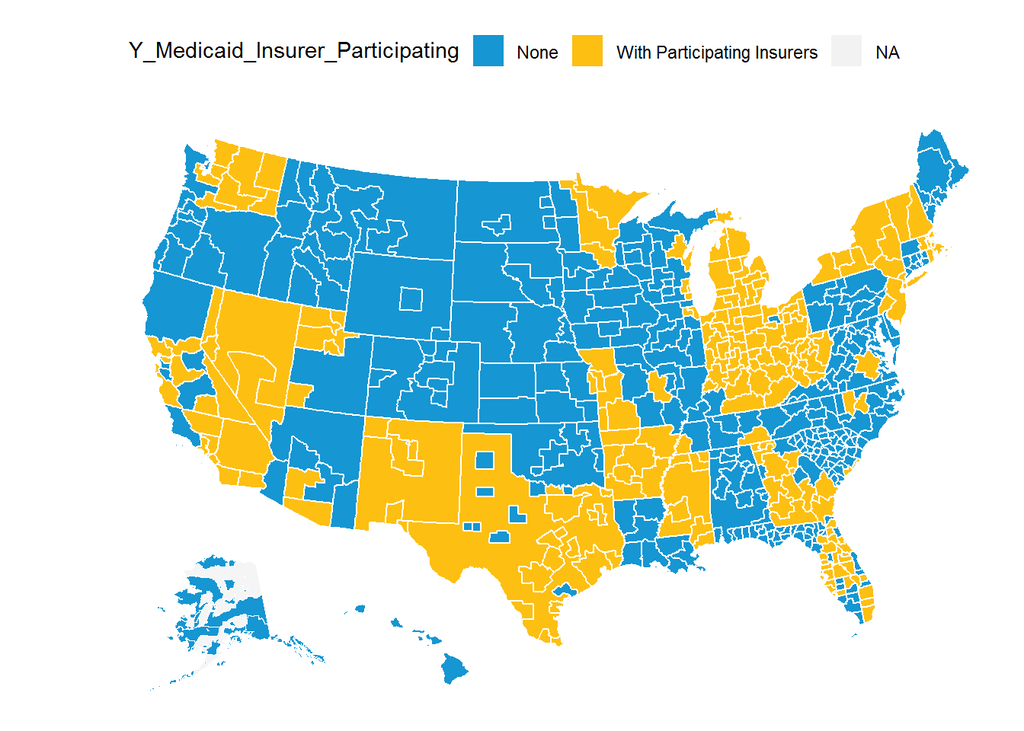

```r
allra <- allra[order(allra$state,allra$ratingarea),]
hpc_data_name <- colnames(allra)[!colnames(allra) %in% c("state","ratingarea","facet","estimate","geometry")]

# Set Data Column
datadim <- quo(!! sym(hpc_data_name[1]))

Data_49 <- filter(allra,(state != "Alaska" & state != "Hawaii"))
Data_AK <- filter(allra,state=="Alaska")
Data_HI <- filter(allra,state=="Hawaii")

# This methods automatically shifts, but renders shifted areas in Alaska appear disconnected on the map
# ggplot() + geom_sf(data=filter(Data_49,facet=="merged"),aes(fill=as.factor(Y_Centene)),color='white') +
  # geom_sf(data=transport_sf(sf=filter(Data_AK,facet=="merged"),shift = c(35, -35), scale = 0.8),aes(fill=as.factor(Y_Centene)),color='white') +
  # geom_sf(data=transport_sf(sf=filter(Data_HI,facet=="merged"),shift = c(52, 5.5), scale = 1.25),aes(fill=as.factor(Y_Centene)),color='white') +
  # coord_sf(xlim = c(-130, -60),ylim = c(20,50)) +
  # coord_sf(projection = "albers",lat0=39, lat1 = 45)
# ggsave(file="graph/harmonise.pdf")

# Plotting 49 with correct projection
Map49 <-
  ggplot() +
    geom_sf(data = filter(Data_49,facet=="merged"),aes(fill=as.factor(eval(datadim))),color='white') +
    coord_sf(crs = st_crs(2163),xlim = c(-2500000, 2500000),ylim = c(-2300000,730000),datum = NA)  +
  scale_fill_manual(name = eval(datadim),values = c("#1696d2","#fdbf11"),labels = c("None","With Participating Insurers","NA")) +
  theme(panel.background = element_rect(fill = "transparent",colour = NA),legend.position = "top")

# Plotting Alaska Separately, Alaska Albers Projection CRS 3467
MapAK <-
  ggplot() +
    geom_sf(data = filter(Data_AK,facet=="merged"),aes(fill=as.factor(eval(datadim))),color='white',size=0.001) +
    coord_sf(crs = st_crs(3467),xlim = c(-2400000, 1600000),ylim = c(200000,2500000),expand = FALSE, datum = NA) +
    scale_fill_manual(values = c("#1696d2","#fdbf11"),na.value="#f5f5f5") +
    theme(legend.position = "none",plot.margin=unit(c(0,0,0,0), "null"),
          panel.background=element_rect(fill = "transparent",colour = NA))

# Plotting Hawaii Separately, Old Hawaii Projection CRS 4135
MapHI <-
  ggplot() +
    geom_sf(data = filter(Data_HI,facet=="merged"),aes(fill=as.factor(eval(datadim))),color='white',size=0.05) +
    coord_sf(crs = st_crs(4135),xlim = c(-161, -154),ylim = c(18,23),expand = FALSE, datum = NA) +
    scale_fill_manual(values = c("#1696d2","#fdbf11")) +
    theme(legend.position = "none",plot.margin=unit(c(0,0,0,0), "null"),
          panel.background=element_rect(fill = "transparent",colour = NA))

# Knit n Mold - through customised annotation option
Map49 +
  annotation_custom(grob = ggplotGrob(MapAK),xmin = -2750000,xmax = -2750000 + (1550000 - (-2400000))/2,ymin = -2450000,ymax = -2450000 + (2000000 - 200000)/2) +
  annotation_custom(grob = ggplotGrob(MapHI),xmin = -1250000,xmax = -1250000 + (-154 - (-164)) * 135000, ymin = -2450000,ymax = -2450000 + (23 - 18) * 135000)
```

```r
# plotname <- paste0("RA Graph ",eval(datadim))
# filename <- paste0(paste0("graph/",plotname[2]),".pdf")
# ggsave(file=filename)
```